# 5_Solutions

Evan Muzzall

2023-05-12

# 1 Challenge 1 - dataframes

1. Open a new script a create a dataframe that contains 6 rows and 3 columns by following the instructions above.
2. Advanced: what is the difference between a data frame and a tidyverse tibble?

```r
# 1.
gpa <- c(3.5, 4.0, 3.3, 2.9, 3.8, 3.5)
school <- c("UC Berkeley", "Stanford", "Stanford", "Stanford", "UC Berkeley", "UC Berkeley")
graduated <- c(T, F, T, F, F, T)

students <- data.frame(gpa, school, graduated)
students
```

| gpa | school | graduated |
| --- | --- | --- |
| 3.5 | UC Berkeley | TRUE |
| 4.0 | Stanford | FALSE |
| 3.3 | Stanford | TRUE |
| 2.9 | Stanford | FALSE |
| 3.8 | UC Berkeley | FALSE |
| 3.5 | UC Berkeley | TRUE |

```r
# or directly within the call to data.frame()
students <- data.frame(gpa = c(3.5, 4.0, 3.3, 2.9, 3.8, 3.5),
                       school = c("UCB", "SU", "SU", "SU", "UCB", "UCB"),
                       graduated = c(T, F, T, F, F, T))
students
```

| gpa | school | graduated |
| --- | --- | --- |
| 3.5 | UCB | TRUE |
| 4.0 | SU | FALSE |
| 3.3 | SU | TRUE |
| 2.9 | SU | FALSE |
| 3.8 | UCB | FALSE |
| 3.5 | UCB | TRUE |

```r
# 2.
# https://jtr13.github.io/cc21fall1/tibble-vs.-dataframe.html#:~:text=10%209.,string%20into%20factor%20by%20default)
```

# 2 Challenge 2 - subsetting

1. Open a new script a create a subset that contains data from DC or stops less than or equal to 7000 and just columns “city” and “traffic_stops”
2. Advanced: use the `filter()` and `select()` functions from the `dplyr` R package to do the same thing (hint: see the dplyr section below!)

```r
#1.
# recreate the dataframe if necessary
police <- data.frame(traffic_stops = c(8814, 9915, 9829, 10161, 6810, 8991),
                     city = as.factor(c("SF", "DC", "DC", "DC", "SF", "SF")),
                     year = as.integer(c(2000, 2000, 2001, 2002, 2001, 2002)))
police
```

| traffic_stops | city | year |
| --- | --- | --- |
| 8814 | SF | 2000 |
| 9915 | DC | 2000 |
| 9829 | DC | 2001 |
| 10161 | DC | 2002 |
| 6810 | SF | 2001 |
| 8991 | SF | 2002 |

```r
# the base R way
dc_7000 <- police[police$city == "DC" |
                    police$traffic_stops <= 7000, c("city", "traffic_stops")]
dc_7000
```

|  | city | traffic_stops |
| --- | --- | --- |
| 2 | DC | 9915 |
| 3 | DC | 9829 |
| 4 | DC | 10161 |
| 5 | SF | 6810 |

```r
# or, the dplyr way!
library(dplyr)
dc_7000 <- police %>%
  filter(city == "DC" | traffic_stops <= 7000) %>%
  select(city, traffic_stops)
dc_7000
```

| city | traffic_stops |
| --- | --- |
| DC | 9915 |
| DC | 9829 |
| DC | 10161 |
| SF | 6810 |

# 3 Challenge 3 - `group_by()` and `mutate()`

While `summarize()` will create a new tibble, `mutate()` creates a new column(s) in an existing tibble.

Open a new script and use the help file for the `mutate()` function that, combined with `group_by()`, creates a new column that computes the average stops per year for the `police` dataframe. (hint: assume there are 365 days in a year!)

```r
# 1.
# recreate the dataframe if necessary
police <- data.frame(traffic_stops = c(8814, 9915, 9829, 10161, 6810, 8991),
                     city = as.factor(c("SF", "DC", "DC", "DC", "SF", "SF")),
                     year = as.integer(c(2000, 2000, 2001, 2002, 2001, 2002)))

avg_stops <- police %>%
  mutate(avg = traffic_stops / 365)
avg_stops
```

| traffic_stops | city | year | avg |
| --- | --- | --- | --- |
| 8814 | SF | 2000 | 24.14795 |
| 9915 | DC | 2000 | 27.16438 |
| 9829 | DC | 2001 | 26.92877 |
| 10161 | DC | 2002 | 27.83836 |
| 6810 | SF | 2001 | 18.65753 |
| 8991 | SF | 2002 | 24.63288 |

# 4 Challenge 4 - .txt import

1. Import the “frankenstein.txt” file from the “novels” subfolder. Save it in a variable named `frank`

```r
# 1.
# Read .txt file to a string
frank <- paste(readLines("data/raw/novels/frankenstein.txt"), collapse="\n")

# With the readr package
# install.packages("readr")
frank <- readr::read_file("data/raw/novels/frankenstein.txt")

# Read the .txt file as a character string
txt_file <- "data/raw/novels/frankenstein.txt"
frank <- readChar(txt_file, file.info(txt_file)$size)
```

# 5 Challenge 5 - line plot

1. Use the gap dataset to figure out a way to use `geom_line()` to create a line plot of average lifeExp through time with a separate line for each continent. Before plotting however, use dplyr to pipe in your `group_by()` and `summarize()` functions directly into ggplot.

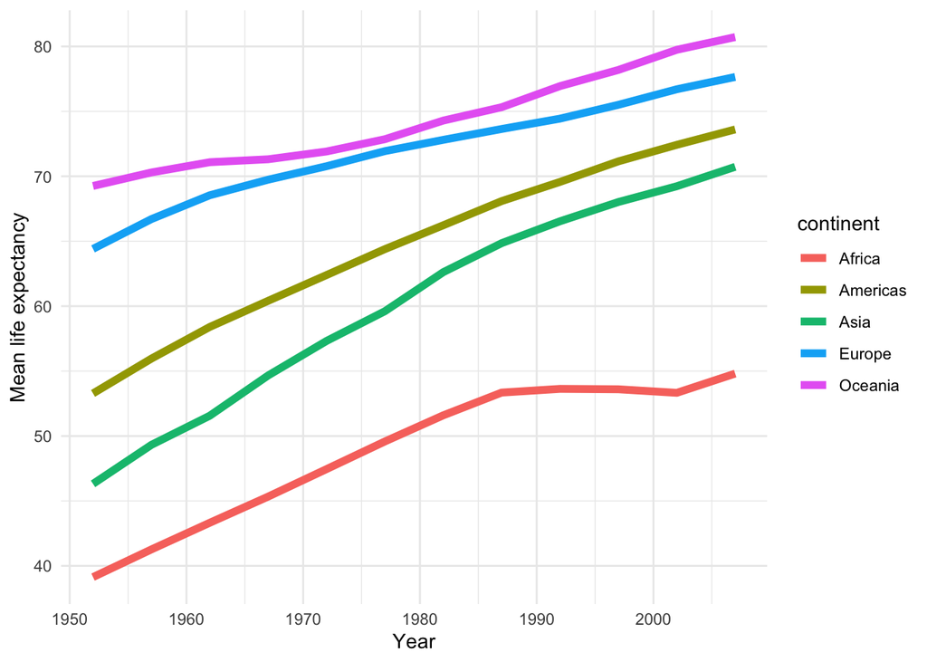

```r
library(dplyr)
library(ggplot2)
gap <- read.csv("data/raw/gapminder-FiveYearData.csv")

gap %>% group_by(continent, year) %>%
  summarize(mean_LE = mean(lifeExp, na.rm = TRUE)) %>%
  ggplot() + geom_line(mapping = aes(x = year, y = mean_LE,
                                     color = continent),
                       lwd = 2) + xlab("Year") + ylab("Mean life expectancy") +
  theme_minimal()
```

# 6 Challenge 6 - summary statistics

1. Install and library the “psych” package and call the help file `?describeBy` to see how to produce this function’s default summary statistics as grouped by continent.

```r
# install.packages("psych")
library(psych)
sum_stats <- psych::describeBy(gap, group = gap$continent)
sum_stats
```

```
##
##  Descriptive statistics by group
## group: Africa
##            vars   n       mean          sd     median    trimmed        mad
## country*      1 624      26.50       15.02      26.50      26.50      19.27
## year          2 624    1979.50       17.27    1979.50    1979.50      22.24
## pop           3 624 9916003.14 15490923.32 4579311.00 6443586.30 5540860.93
## continent*    4 624       1.00        0.00       1.00       1.00       0.00
## lifeExp       5 624      48.87        9.15      47.79      48.30       8.58
## gdpPercap     6 624    2193.75     2827.93    1192.14    1557.04     775.32
##                 min          max        range skew kurtosis        se
## country*       1.00        52.00        51.00 0.00    -1.21      0.60
## year        1952.00      2007.00        55.00 0.00    -1.22      0.69
## pop        60011.00 135031164.00 134971153.00 3.55    17.02 620133.24
## continent*     1.00         1.00         0.00  NaN      NaN      0.00
## lifeExp       23.60        76.44        52.84 0.56     0.13      0.37
## gdpPercap    241.17     21951.21     21710.05 3.53    15.78    113.21
## ------------------------------------------------------------
## group: Americas
##            vars   n        mean          sd     median    trimmed        mad
## country*      1 300       13.00        7.22      13.00       13.0       8.90
## year          2 300     1979.50       17.29    1979.50     1979.5      22.24
## pop           3 300 24504795.00 50979430.20 6227510.00 10642390.8 5972602.95
## continent*    4 300        1.00        0.00       1.00        1.0       0.00
## lifeExp       5 300       64.66        9.35      67.05       65.5       8.47
## gdpPercap     6 300     7136.11     6396.76    5465.51     5823.6    3269.33
##                  min          max        range  skew kurtosis         se
## country*        1.00        25.00        24.00  0.00    -1.22       0.42
## year         1952.00      2007.00        55.00  0.00    -1.23       1.00
## pop        662850.00 301139947.00 300477097.00  3.37    11.43 2943298.78
## continent*      1.00         1.00         0.00   NaN      NaN       0.00
## lifeExp        37.58        80.65        43.07 -0.73    -0.21       0.54
## gdpPercap    1201.64     42951.65     41750.02  2.83     9.42     369.32
## ------------------------------------------------------------
## group: Asia
##            vars   n        mean           sd      median     trimmed
## country*      1 396       17.00         9.53       17.00       17.00
## year          2 396     1979.50        17.28     1979.50     1979.50
## pop           3 396 77038721.97 206885204.62 14530830.50 25678311.84
## continent*    4 396        1.00         0.00        1.00        1.00
```

[output cut: 33 more lines]

```
## group: Oceania
##            vars  n       mean         sd     median    trimmed        mad
## country*      1 24       1.50       0.51       1.50       1.50       0.74
## year          2 24    1979.50      17.63    1979.50    1979.50      22.24
## pop           3 24 8874672.33 6506342.47 6403491.50 8439348.35 5996394.97
## continent*    4 24       1.00       0.00       1.00       1.00       0.00
## lifeExp       5 24      74.33       3.80      73.66      74.19       4.00
## gdpPercap     6 24   18621.61    6358.98   17983.30   18059.97    6459.10
##                   min         max       range skew kurtosis         se
## country*         1.00        2.00        1.00 0.00    -2.08       0.10
## year          1952.00     2007.00       55.00 0.00    -1.36       3.60
## pop        1994794.00 20434176.00 18439382.00 0.43    -1.48 1328101.59
## continent*       1.00        1.00        0.00  NaN      NaN       0.00
## lifeExp         69.12       81.24       12.11 0.37    -1.33       0.77
## gdpPercap    10039.60    34435.37    24395.77 0.71    -0.21    1298.02
```